# AnalysisLin-vignette

## Data Visualization

### Numeric Plot

To visualize histogram for all numerical variables

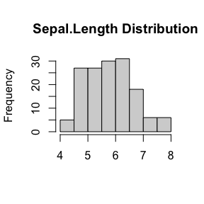

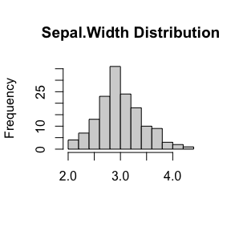

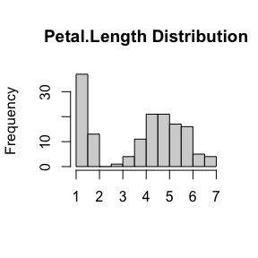

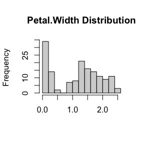

```
## list()
```

```r
numeric_plot(iris)
```

if you want to add distribution curve over histogram:

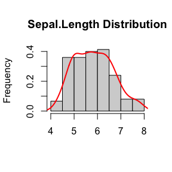

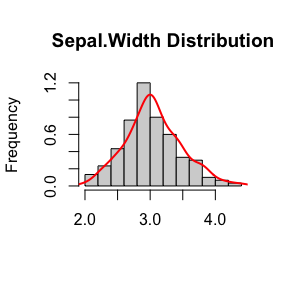

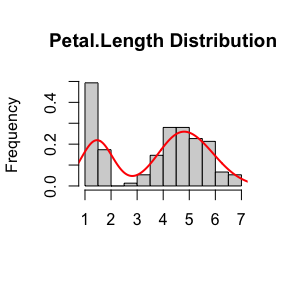

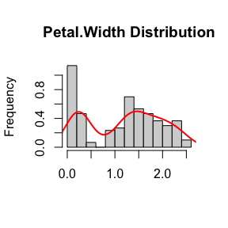

```
## list()
```

```r
numeric_plot(iris,prob=T,dens=T)
```

### Categorical Plot

To visualize bar/pie charts for all categorical variables

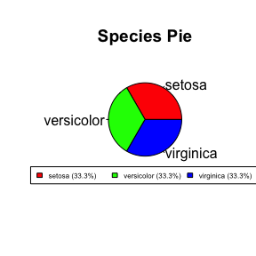

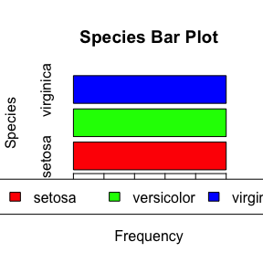

```r
categoric_plot(iris,bar_width = 1)
```

if you just want bar or pie chart:

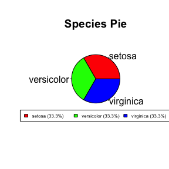

```r
categoric_plot(iris,bar=F)
```

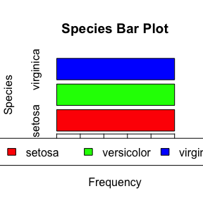

```r
categoric_plot(iris,pie=F)
```

## Correlation Analysis

### Correlation Matrix

To visualize correlation table for all variables.

```r
corr_matrix(mtcars)
```

```
##     row column         cor            p
## 3   cyl   disp  0.90203287 1.803002e-12
## 13 disp     wt  0.88797992 1.222311e-11
## 11  mpg     wt -0.86765938 1.293958e-10
## 1   mpg    cyl -0.85216196 6.112688e-10
## 2   mpg   disp -0.84755138 9.380328e-10
## 5   cyl     hp  0.83244745 3.477861e-09
## 23  cyl     vs -0.81081180 1.843018e-08
## 45   am   gear  0.79405876 5.834043e-08
## 6  disp     hp  0.79094859 7.142679e-08
## 12  cyl     wt  0.78249579 1.217567e-07
## 4   mpg     hp -0.77616837 1.787835e-07
## 49   hp   carb  0.74981247 7.827810e-07
## 28 qsec     vs  0.74453544 1.029669e-06
## 25   hp     vs -0.72309674 2.940896e-06
```

[output cut: 41 more lines]

if you want to visualize correlation map along with correlation table:

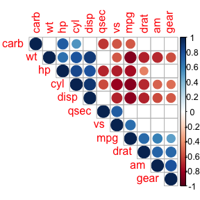

```
##     row column         cor            p
## 3   cyl   disp  0.90203287 1.803002e-12
## 13 disp     wt  0.88797992 1.222311e-11
## 11  mpg     wt -0.86765938 1.293958e-10
## 1   mpg    cyl -0.85216196 6.112688e-10
## 2   mpg   disp -0.84755138 9.380328e-10
## 5   cyl     hp  0.83244745 3.477861e-09
## 23  cyl     vs -0.81081180 1.843018e-08
## 45   am   gear  0.79405876 5.834043e-08
## 6  disp     hp  0.79094859 7.142679e-08
## 12  cyl     wt  0.78249579 1.217567e-07
## 4   mpg     hp -0.77616837 1.787835e-07
## 49   hp   carb  0.74981247 7.827810e-07
## 28 qsec     vs  0.74453544 1.029669e-06
## 25   hp     vs -0.72309674 2.940896e-06
```

[output cut: 41 more lines]

```r
corr_matrix(mtcars,corrplot=T)
```

you may also choose type of correlation:Pearson correlation and Spearman correlation.

```r
corr_matrix(mtcars,type='pearson')
corr_matrix(mtcars,type='spearman')
```

### Correlation Clustering

Correlation clustering partitioning data points into groups based on their similarity(correlation)

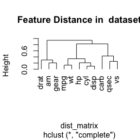

```r
corr_cluster(mtcars,type='pearson')
```

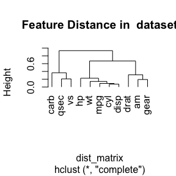

```r
corr_cluster(mtcars, type='spearman')
```

## Feature_Engineering

### Missing Value Imputation

Imputing mssing value is a way to get more information from a data with missing values. However, one need to carefully choose what method to use to impute missing values in order to reach most accuracy.

- **mean**: use mean value to replace missing value.

```r
impute_missing(airquality,method='mean')
```

```
##         Ozone  Solar.R Wind Temp Month Day
## 1    41.00000 190.0000  7.4   67     5   1
## 2    36.00000 118.0000  8.0   72     5   2
## 3    12.00000 149.0000 12.6   74     5   3
## 4    18.00000 313.0000 11.5   62     5   4
## 5    42.12931 185.9315 14.3   56     5   5
## 6    28.00000 185.9315 14.9   66     5   6
## 7    23.00000 299.0000  8.6   65     5   7
## 8    19.00000  99.0000 13.8   59     5   8
## 9     8.00000  19.0000 20.1   61     5   9
## 10   42.12931 194.0000  8.6   69     5  10
## 11    7.00000 185.9315  6.9   74     5  11
## 12   16.00000 256.0000  9.7   69     5  12
## 13   11.00000 290.0000  9.2   66     5  13
## 14   14.00000 274.0000 10.9   68     5  14
```

[output cut: 139 more lines]

- **mode**: use most frequency value to replace missing value.
- **median**: use median value to replace missing value.
- **locf**: use last observation value to replace missing value.
- **knn**: use k-nearest nerighbor to replace missing value, k needs to be chosen.

```r
impute_missing(airquality,method='mode')
impute_missing(airquality,method='median')
impute_missing(airquality,method='locf')
impute_missing(airquality,method='knn',k=5)
```

### Principle Component Analysis

Principle Component Analysis can help you to reduce the number of variables in a dataset. To perform and visualize PCA on some selected variables

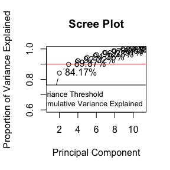

```
## PCA Analysis Results:
## ==========================
## Total number of variables: 11
## Number of principal components retained: 4
## Total cumulative variance explained: 92.32 %
##
```

```
## $rotation_matrix
##             PC1         PC2         PC3          PC4
## mpg  -0.3625305  0.01612440 -0.22574419 -0.022540255
## cyl   0.3739160  0.04374371 -0.17531118 -0.002591838
## disp  0.3681852 -0.04932413 -0.06148414  0.256607885
## hp    0.3300569  0.24878402  0.14001476 -0.067676157
## drat -0.2941514  0.27469408  0.16118879  0.854828743
## wt    0.3461033 -0.14303825  0.34181851  0.245899314
## qsec -0.2004563 -0.46337482  0.40316904  0.068076532
## vs   -0.3065113 -0.23164699  0.42881517 -0.214848616
## am   -0.2349429  0.42941765 -0.20576657 -0.030462908
## gear -0.2069162  0.46234863  0.28977993 -0.264690521
## carb  0.2140177  0.41357106  0.52854459 -0.126789179
##
## $scores_matrix
##                               PC1        PC2        PC3          PC4
## Mazda RX4           -0.6468627420  1.7081142 -0.5917309  0.113702214
## Mazda RX4 Wag       -0.6194831460  1.5256219 -0.3763013  0.199121210
## Datsun 710          -2.7356242748 -0.1441501 -0.2374391 -0.245215450
## Hornet 4 Drive      -0.3068606268 -2.3258038 -0.1336213 -0.503800355
## Hornet Sportabout    1.9433926844 -0.7425211 -1.1165366  0.074461963
## Valiant             -0.0552534228 -2.7421229  0.1612456 -0.975167425
## Duster 360           2.9553851233  0.3296133 -0.3570461 -0.051529216
## Merc 240D           -2.0229593244 -1.4421056  0.9290295 -0.142129082
## Merc 230            -2.2513839535 -1.9522879  1.7689364  0.287210957
## Merc 280            -0.5180912217 -0.1594610  1.4692603  0.066263362
## Merc 280C           -0.5011860079 -0.3187934  1.6570701  0.094357222
## Merc 450SE           2.2124096339 -0.6727099 -0.3694707 -0.129797905
## Merc 450SL           2.0155715693 -0.6724606 -0.4768341 -0.210991001
## Merc 450SLC          2.1147047372 -0.7891129 -0.2904620 -0.175332868
## Cadillac Fleetwood   3.8383725118 -0.8149087  0.6370972  0.290505877
## Lincoln Continental  3.8918495626 -0.7218314  0.7092612  0.405336898
## Chrysler Imperial    3.5363862158 -0.4145024  0.5402468  0.665665306
## Fiat 128            -3.7955510831 -0.2920783 -0.4161681  0.055191058
## Honda Civic         -4.1870356784  0.6775721 -0.2035831  1.167526096
## Toyota Corolla      -4.1675359344 -0.2748890 -0.4589124  0.183313028
## Toyota Corona       -1.8741790870 -2.0864529  0.1543265  0.050514126
## Dodge Challenger     2.1504414942 -0.9982442 -1.1503639 -0.584982249
## AMC Javelin          1.8340369797 -0.8921886 -0.9472872  0.005694071
## Camaro Z28           2.8434957523  0.6701037 -0.1605593  0.814340105
## Pontiac Firebird     2.2105479148 -0.8600504 -1.0279577  0.146420497
## Fiat X1-9           -3.5176818134 -0.1192950 -0.4464716 -0.013427353
## Porsche 914-2       -2.6095003965  2.0141425 -0.8172519  0.568564789
## Lotus Europa        -3.3323844512  1.3568877 -0.4467167 -1.153197531
## Ford Pantera L       1.3513346957  3.4448780 -0.1343943  0.590098358
## Ferrari Dino        -0.0009743305  3.1683750  0.3957610 -0.938933017
## Maserati Bora        2.6270897605  4.3107016  1.3315940 -0.877332804
## Volvo 142E          -2.3824711412  0.2299603  0.4052798  0.223549117
```

```r
automate_pca(mtcars,variance_threshold = 0.9)
```